# Near a Hospital, Near a Pharmacy?

Two perspectives on geographic proximity to healthcare facilities

## Story summary

Does living near one type of healthcare facility imply living near another? Of 2,345 urban centres with both proximity measurements available, the median share of residents living within one kilometre of a hospital is 31.8%, compared with 18.8% for a pharmacy.

However, this comparison does not establish whether individuals are closer to hospitals compared to pharmacies within individual cities. Comparing the two measures shows that hospital proximity is higher in 68.7% of urban centres, while pharmacy proximity is higher in 717 cities and the two measures are equal in 18. The median difference within each city is 9.47 percentage points towards the proximity of hospitals.

The story therefore goes from an overall contrast to a more nuanced image: hospital proximity is usually higher, but not everywhere. Proximity to one facility type does not imply equivalent proximity to another.

These findings describe the subset of urban centres with both measurements available. Geographic proximity is measured, not healthcare quality, affordability, capacity, or actual use.

## Version A: Scientific article

### Comparing the distributions

Proximity to pharmacy and hospital describe different aspects of geographic access. First, we will compare their distributions across the same 2,345 urban centres, giving each urban centre equal weight.

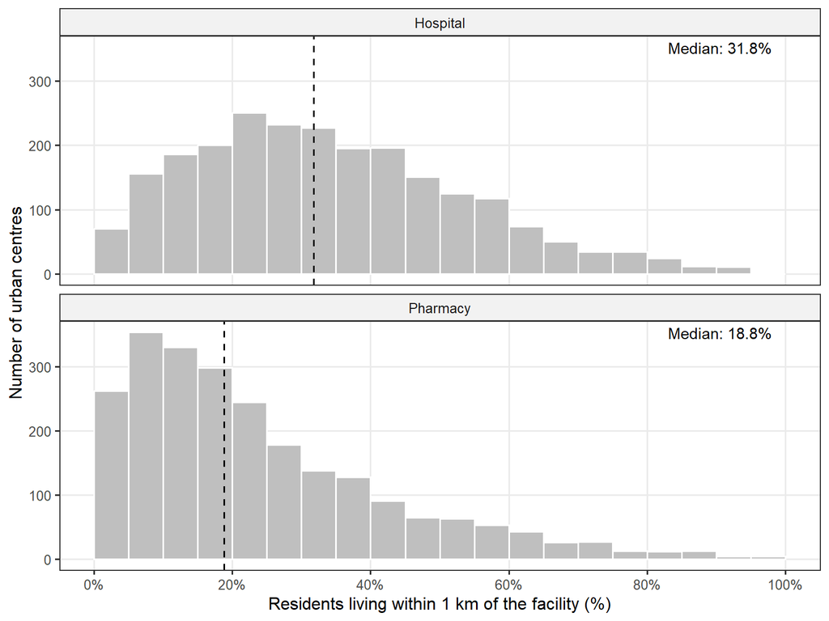

Figure 1: Distribution of population proximity to hospitals and pharmacies in the matched sample. Each observation is an urban centre; bars represent 5-percentage-point intervals. Dashed lines indicate medians. Both panels use identical scales.

Median hospital proximity is 31.8%, compared with 18.8% for pharmacies. These are medians of city-level population shares, not estimates for the combined population of all sampled cities.

These distributions showcase the overall pattern.However, they do not inform us how often hospital proximity is closer than pharmacy proximity within the same city. To address this issue, we compare these two measures within each urban centre.

### Comparing facilities within cities

For each urban centre, we subtract pharmacy proximity from hospital proximity. A positive difference implies higher hospital proximity, whereas a negative difference indicates higher pharmacy proximity. Differences are expressed in percentage points.

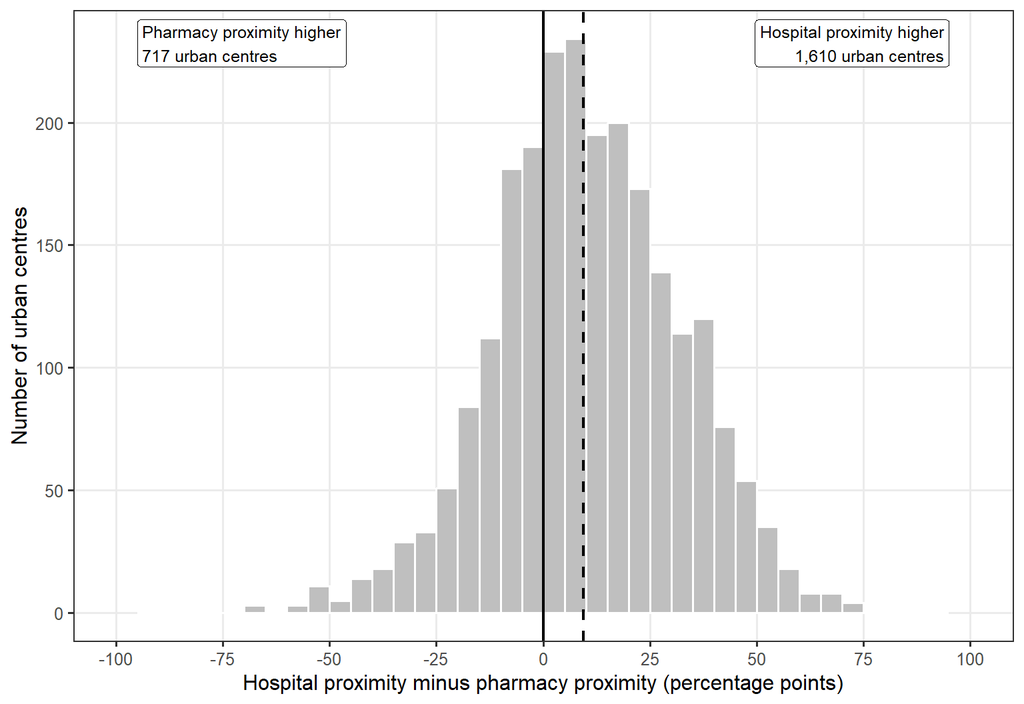

Figure 2: Within-city differences in population proximity to hospitals and pharmacies among 2,345 urban centres. Bars represent 5-percentage-point intervals. The solid vertical line marks equal proximity; the dashed line marks the median difference of 9.47 percentage points. Eighteen urban centres have equal proximity.

Hospital proximity is greater than pharmacy proximity in 1,610 of the 2,345 urban centres (68.7%). Pharmacy proximity is higher in 717 urban centres, while 18 have equal proximity. The median within-city difference is 9.47 percentage points in favour of hospitals.

Comparing both measures within each urban centre presents that hospital proximity is higher in most, but not all cities. Moreover, the median within-city difference is not the difference between the two separate medians. First, we calculate the difference for each urban centre, then we take the median of those differences.

These results are descriptive the urban centres with data available for both measures. Importantly, They do not explain the reason for the differences, or tell us about healthcare quality, capacity or affordability.

## Version B: Accessible explainer

### More residents live near hospitals in the typical city

A hospital and a pharmacy serve different needs. Being geographically close to one does not necessarily mean being close to the other.

We compared the share of residents living within one kilometre of each facility type in 2,345 urban centres with both measurements available. The hospital percentage is higher in the typical city in this sample.

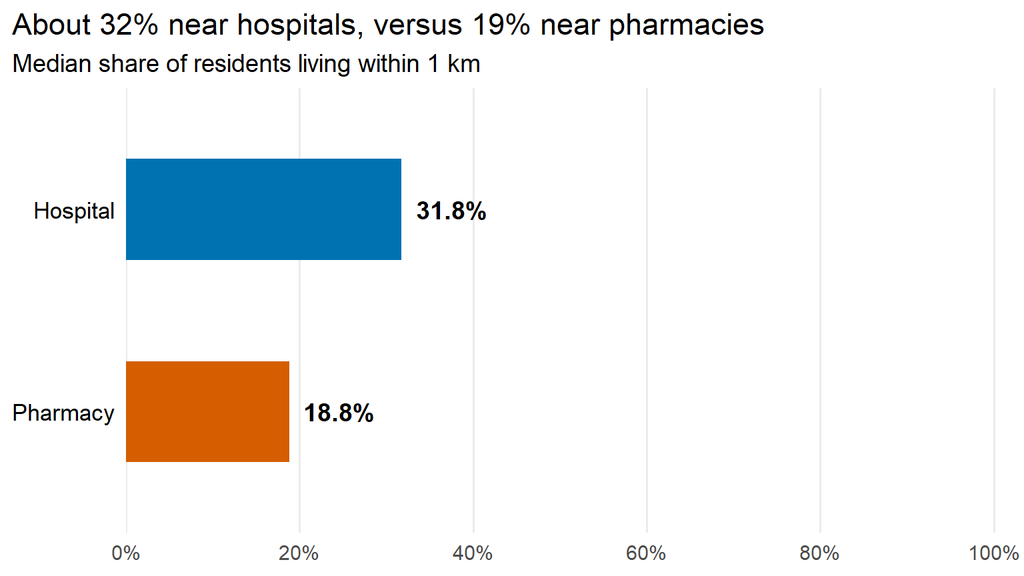

Figure 3: Median city-level proximity in the same 2,345 urban centres. These percentages do not describe the combined population of the sampled cities.

“Typical” here means the median urban centre: half the cities have proximity at or below that value, and half at or above it. Each city has an equal weight regardless of population.

Nonetheless, these two summary values leave one question unanswered. Is proximity to hospitals greater than proximity to pharmacies in most cities, or does focusing on each city separately of each other show a different story?

### But the hospital advantage is not universal

To answer that question, we compared hospital and pharmacy proximity within each city. Hospital proximity is higher in holds in about seven out of ten urban centres, but there are hundreds of cities where this is not the case.

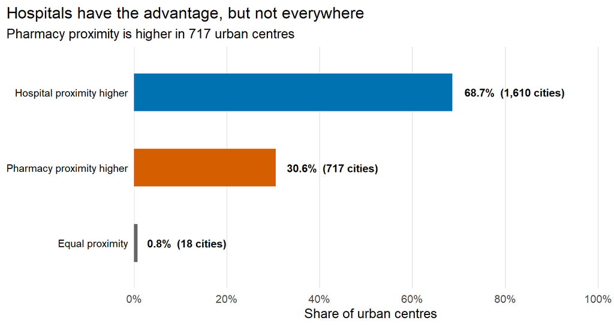

Figure 4: Within-city comparison for 2,345 urban centres with both measurements available. Percentages describe cities, not the combined population. Rounded percentages may not total exactly 100%.

Hospital proximity is higher in 1,610 cities, while pharmacy proximity is higher in 717. The other 18 cities have equal proximity.

How big is the difference between the two? Of the urban centres that have data for both measures, the median difference is 9.47 percentage points. For example, 40% of a city’s population is near a hospital and 30% is near a pharmacy, this would represent a 10 percentage point gap in favor of hospitals. This example serves to explain the unit and is not a reported city measurement.

The takeaway is not that it is easier to reach hospitals at all times. Instead, it is that hospital and pharmacy proximity each have different meanings, and that a city can have the majority of its population near one more than the other.

To end off, being within one kilometre of one facility does not tell us if people can afford its benefits, whether that facility has enough staff, or how easily they can get to the facility.These results only tell us geographic proximity of people to the facilities in urban centres with available data, not whether the healthcare quality of each facility is up to their expectations.

## Data and source note

### Source and measurement

This analysis uses `health.csv` from the [TidyTuesday release of 29 September 2026](https://github.com/rfordatascience/tidytuesday/blob/main/data/2026/2026-09-29/readme.md). The underlying source is the European Commission Joint Research Centre’s Global Human Settlement Urban Centre Database, GHS-UCDB R2024A: GHS Urban Centre Database 2025.

The unit of analysis is an urban centre as delineated in that database, not necessarily an administrative municipality.

The analysis uses two indicators:

- `HL_SHP_HOS_2025`: share of the urban-centre population living within a 1 km buffer of a hospital.
- `HL_SHP_PHA_2025`: share living within a 1 km buffer of a pharmacy.

In the supplied CSV, these values are expressed on a 0–100 percentage scale. They are not multiplied by 100 during analysis.

### Analytical sample and missing values

The dataset contains 11,422 urban centres. Hospital proximity is missing for 4,988 and pharmacy proximity for 8,952. These missingness counts overlap.

The analysis retains the 2,345 urban centres with both proximity measurements available—approximately one-fifth of the original dataset. The same matched sample is used throughout both presentation versions. Missing values are excluded, not interpreted as zero proximity. Income-group information and city names are not required for inclusion.

The reasons for missingness are not established in this analysis. The retained cities may differ systematically from excluded cities. Consequently, these results should not be treated as representative estimates for all urban centres worldwide.

### Calculations and interpretation

Each urban centre receives equal weight. The medians and comparison percentages therefore describe cities, not the combined population of all cities.

For each city, the paired difference is calculated as:

**Hospital proximity − pharmacy proximity**

A positive difference means higher proximity to hospitals; a negative difference suggests higher proximity to pharmacies. Differences are measured in percentage points.

The median difference within each city is calculated from the individual city-level differences. It is not calculated by subtracting the two separate facility medians.

Both scientific histograms use 5-percentage-point intervals. The accessible figures summarize the same sample using facility medians and the proportions of cities with positive, negative, or zero differences. Displayed values are rounded.

### Limitations

A one-kilometre buffer measures geographic proximity. It does not measure many other aspects related to this measure, such as time to travel to the facility, route accessibility, how affordable each facility is, or healthcare quality.

Hospitals and pharmacies provide different services. Higher proximity to one facility type does not mean that can replace the other or that a city’s healthcare provision is adequate.

This analysis is descriptive. No causal effects or population-level inferential claims are estimated and no confidence intervals are presented: the figures summarize the available-data sample, and uncertainty about coverage and missingness is not resolved by these descriptive summaries.

## Generative AI disclosure

I used Perplexity, a generative AI assistant, to help me in this assignment. AI assistance helped in exploring the dataset, clarifying what the data is about, helped me with the R code for data import, cleaning, descriptive calculations, visualization, and preparation of the Quarto document.

I requested help adapting the same story for scientific and more general audiences, drafting the story summary, explanatory prose figure captions, accessibility text, and data/source note. This was done by asking for step by step information on these steps as well as Quarto guidance explaining each step so I could apply and understand the code. Percentage scaling, missing variables, plot labelling, axis limits, and document rendering was part of those steps mentioned and explained.

The assistance included proposed code and text that I incorporated into the deliverable, rather than only editing material I had written. I ran the code and inspected the resulting outputs. Some initial AI-generated suggestions and code required correction during the workflow.

[output not shown]

### Prompt

```
this is the data [https://github.com/rfordatascience/tidytuesday/blob/main/data/2026/2026-09-29/readme.md](https://github.com/rfordatascience/tidytuesday/blob/main/data/2026/2026-09-29/readme.md) . what code is available for these visualizations
```

### Prompt

```
you wrote a lot of code. i just want to know how to make 4 figures and understand the code so give me a step by step guide to make these 4 figures you mentioned. i will open rstudio
```

### Prompt — Figure 3 error

```
says this
```

Attachment: RStudio screenshot showing the error that `label_number_si()` is no longer supported.

### Prompt — Request to simplify Figure 4

```
the thing is, the last figure is very complicated and ugly with the labelling of countries. i want it to be simpler to understand
```

### Prompt — Figure 4 error screenshot

```
image.jpg
```

Attachment: RStudio screenshot showing the error `object 'city_country' not found`.

### Prompt — Request to improve Figure 4

```
all the bars are red. i want to make this a memorable figure remember, so i don't want all red. also the x axis is muddled up and is hard to tell what is going on. i want this to be simpler, memorable, and easier to understand the story
```

Attachment: Screenshot of the initial horizontal bar chart for Figure 4.

### Prompt — Resume work in the saved project

```
i see my code, now proceed
```

### Prompt — Clarification

```
is the script the top left below figure 4 or in the console
```

### Prompt — Missing-value output screenshot

```
image.jpg
```

Attachment: RStudio screenshot showing the missing-value diagnostic results, including 2,345 urban centres with both proximity measures.

### Prompt — Results table

```
# A tibble: 1 × 12
  cities hospital_min hospital_max pharmacy_min pharmacy_max median_hospital_pct
   <int>        <dbl>        <dbl>        <dbl>        <dbl>               <dbl>
1   2345      0.00182         94.7      0.00376         98.9                31.8
  median_pharmacy_pct median_difference_pp hospital_higher_n pharmacy_higher_n equal_n
                <dbl>                <dbl>             <int>             <int>   <int>
1                18.8                 9.47              1610               717      18
  hospital_higher_percent
                    <dbl>
1                    68.7
```

### Prompt — Scientific Figure 1 completed

```
it worked
```

### Prompt — Scientific Figure 2 completed

```
it worked
```

### Prompt — Accessible Figure 1 completed

```
it worked
```

### Prompt — Clarify code placement

```
for step 2 do i should this code be in line 15
```

Attachment: RStudio screenshot showing the header of index.qmd and the blank line above the Story summary heading.

### Prompt — Check code placement

```
like this?
```

Attachment: RStudio screenshot showing the end of the setup code chunk and the Story summary heading.

### Prompt — Quarto rendering error

[output not shown]

### Prompt — Scientific Figure 1 appears on the webpage

```
figure 1 appears
```

### Prompt — Scientific Figure 2 appears on the webpage

```
figure 2 appears
```

### Prompt — Accessible Figure 1 appears on the webpage

```
accessible figure 1 appears
```

### Prompt — Accessible Figure 2 appears on the webpage

```
accessible figure 2 appears
```

### Prompt — Source-note confirmation

```
source not appears
```

### Prompt — Clarify source-note visibility

```
visible
```